# ENM Day 1: Introduction

# 1 Aggregating Rasters

Loading libraries

```r
library(raster)
library(rgdal)
library(maptools)
library(here)
```

Set your paths

```r
## path to original layers
path2layers <- here("layers", "lidar","original_vars")

## path to aggregated layers
path2agglayers <- here("layers", "lidar","agregated_vars")
```

## 1.1 Load environmental variables

stack() create one file with several rasters.To have a tsack everything should be having teh same px size and original coordinates.

```r
layers<-list.files(path=path2layers,pattern='asc',full.names=TRUE)
#layers to chack whetehr all is loaded

egv<-stack(layers)## Join all rasters in a single object
```

- check the structure of the rasters

```r
print(egv)
```

```
class      : RasterStack
dimensions : 268, 197, 52796, 5  (nrow, ncol, ncell, nlayers)
resolution : 1, 1  (x, y)
extent     : 587674, 587871, 4631485, 4631753  (xmin, xmax, ymin, ymax)
crs        : NA
names      : mda, mds, mdt, rug, slp
```

268 rows, 197 columns 52796 px and 5 variables resolution 1m names: names of var

- check descriptive statistics of the rasters

```r
summary(egv)
```

## 1.2 Plot the stack

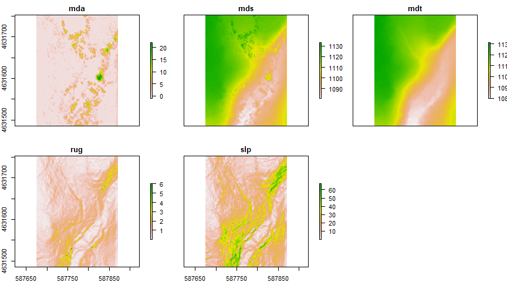

```r
plot(egv)
```

## 1.3 Aggregate raster

agregate the stack so you dont have to do it for each stack.

‘aggregate()’ input parameters: object; number of pixels to aggregate (10).

```r
agg<-aggregate(egv,10,fun=mean)
```

- check the structure of the aggregated rasters

```r
print(agg)
```

```
class      : RasterBrick
dimensions : 27, 20, 540, 5  (nrow, ncol, ncell, nlayers)
resolution : 10, 10  (x, y)
extent     : 587674, 587874, 4631483, 4631753  (xmin, xmax, ymin, ymax)
crs        : NA
source     : memory
names      :         mda,         mds,         mdt,         rug,         slp
min values :    0.000000, 1082.225000, 1080.525000,    0.108710,    2.028029
max values :   15.010000, 1131.360000, 1131.000000,    2.564869,   45.348747
```

check teh new resolution - should be 10m

- check descriptive statistics of the aggregated rasters

```r
summary(agg)
```

```
         [,1]     [,2]     [,3]      [,4]      [,5]
Min.     0.00 1082.225 1080.525 0.1087100  2.028029
1st Qu.  0.05 1096.248 1094.740 0.4210865  9.184954
Median   0.26 1111.180 1110.575 0.6727450 14.748836
3rd Qu.  1.29 1120.943 1120.302 1.1279975 23.781116
Max.    15.01 1131.360 1131.000 2.5648690 45.348747
NA's     0.00    0.000    0.000 0.0000000  0.000000
```

## 1.4 Loop to export sequentially aggregated stack

remove stack and separate evrything as a separate raster

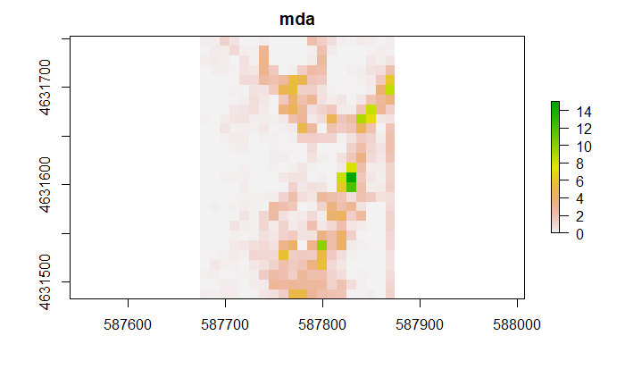

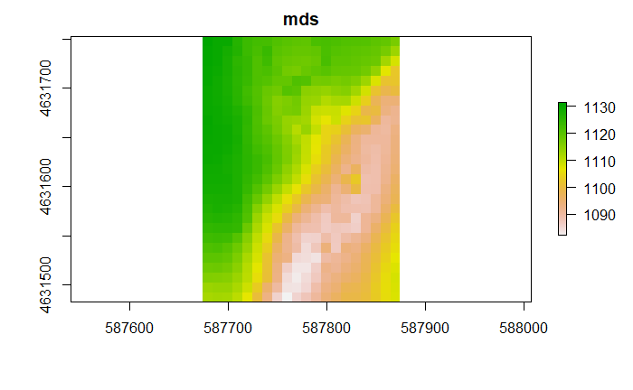

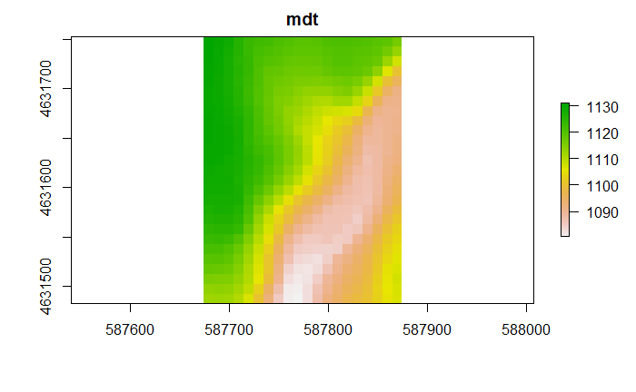

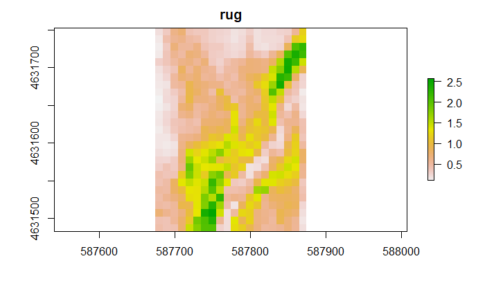

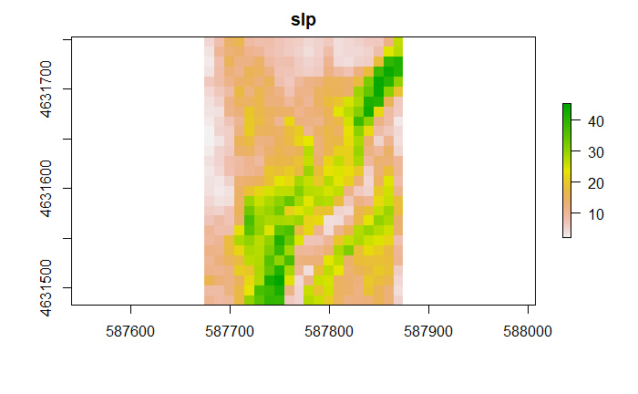

```r
for (i in 1:5) { # there are 5 bands
  # Select a band sequentially
  r<-agg[[i]]
  # Plot the selected band
  plot(r,main = r@data@names)
  # Get name of the band
  name <- r@data@names
  # export the raster to a folder using paste
  writeRaster(r, filename=paste(path2agglayers,name,sep=''), format="ascii", overwrite=TRUE)
}
```

# 2 Clipping Rasters

QGIC to create clipping shapefile: shapefile should be polygons cordinate system WOS create attributes

NAtural https://www.naturalearthdata.com/downloads/10m-physical-vectors/ =>downloads

setting paths

```r
# path to aggregated layers
path2agglayers<-here("layers","lidar","aggregated_vars")
# clipping shapefile
path2clipshp<-here("layers","lidar","clipping_area.shp")
# path to clipped layers
path2cliplayers<-here("layers","lidar","clipped_vars")
```

Load aggregated environmental variables

```r
layers<-list.files(path=path2agglayers,pattern='asc',full.names=TRUE)
```

## 2.1 Join all rasters in a single object

```r
egv<-stack(layers)
```

## 2.2 check the structure of the rasters

```r
print(egv)
```

```
class      : RasterStack
dimensions : 27, 20, 540, 5  (nrow, ncol, ncell, nlayers)
resolution : 10, 10  (x, y)
extent     : 587674, 587874, 4631483, 4631753  (xmin, xmax, ymin, ymax)
crs        : NA
names      : mda, mds, mdt, rug, slp
```

## 2.3 check descriptive statistics of the rasters

```r
summary(egv)
```

```
          mda      mds      mdt       rug       slp
Min.     0.00 1082.225 1080.525 0.1087100  2.028029
1st Qu.  0.05 1096.248 1094.740 0.4210865  9.184954
Median   0.26 1111.180 1110.575 0.6727450 14.748836
3rd Qu.  1.29 1120.943 1120.303 1.1279975 23.781116
Max.    15.01 1131.360 1131.000 2.5648689 45.348747
NA's     0.00    0.000    0.000 0.0000000  0.000000
```

## 2.4 Plot the stack

call x11() if the following plot is not represented correctly: with x11 a new window is open

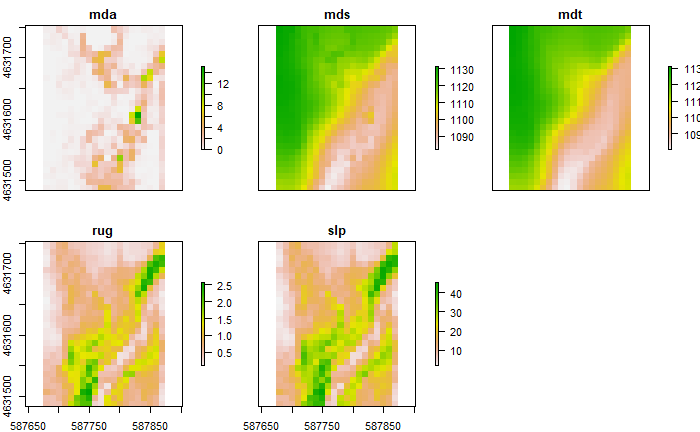

```r
plot(egv)
```

## 2.5 Load study area shapefile

shapefile and rasters can be read by readOGR

```r
shp <- readOGR(path2clipshp)
```

## 2.6 Plot the shapefile

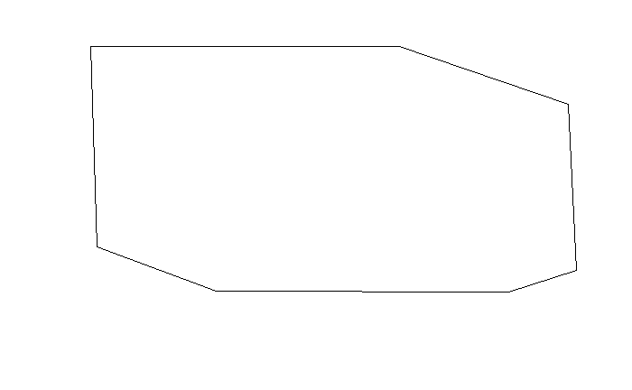

```r
plot(shp)
```

## 2.7 Loop to clip each raster sequentially

because we have a stack: same function applied for each raster

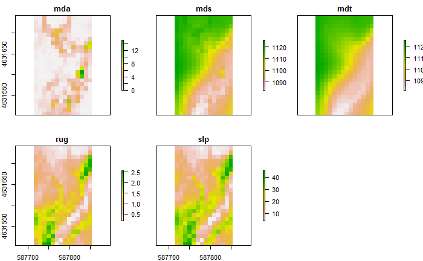

```r
# clip raster
# the raster to be clipped; the clipping feature; snap determines in which direction the extent should be aligned
# to the nearest border, inwards )(in) or outwards (out). in mins crop inside
clip.r<-crop(egv, shp, snap="in")
# plot the clipped raster
plot(clip.r,main=clip.r@data@names)
```

```r
NA
NA
```

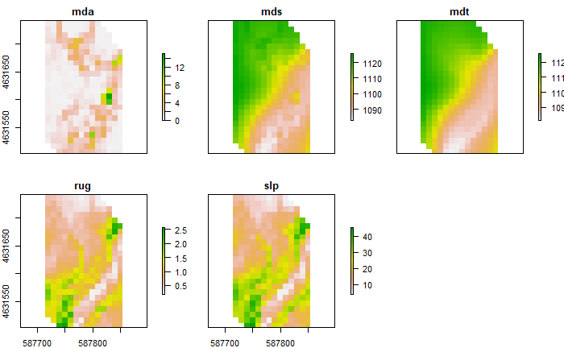

```r
#mask raster with the shapefile to create NoData. masking does not delete px
mask.r <- mask(clip.r, shp)
# plot the masked raster
plot(mask.r,main = mask.r@data@names)
```

```r
for (i in nlayers(mask.r)) { # look for each ascii file in layers
  # Get name of the band
  mask.r.i <- mask.r[[i]]
  name<- mask.r.i@data@names
  # export the raster to a folder using paste
  writeRaster(mask.r.i,paste(path2cliplayers,"clip_",name,sep=''),format="ascii", overwrite=TRUE)
}
```

## 2.8 plot all clipped variables

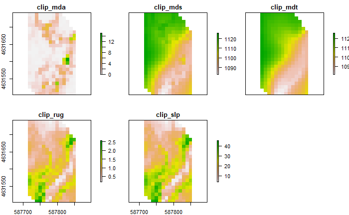

```r
files<-list.files(path=path2cliplayers,pattern='asc',full.names=TRUE)
# Join all rasters in a single object
clips<-stack(files)
plot(clips)
```

# 3 Correlation

Loading paths

```r
# path to clipped layers
path2cliplayers<-here("layers","lidar","clipped_vars")
# path to correlation folder
path2corr<-here("layers","lidar")
```

Load environmental variables

```r
layers<-list.files(path=path2cliplayers,pattern='asc',full.names=TRUE)
#Join all rasters in a single object
egv<-stack(layers)
```

- check the structure of the rasters

```r
print(egv)
```

```
class      : RasterStack
dimensions : 24, 14, 336, 5  (nrow, ncol, ncell, nlayers)
resolution : 10, 10  (x, y)
extent     : 587714, 587854, 4631503, 4631743  (xmin, xmax, ymin, ymax)
crs        : NA
names      : clip_mda, clip_mds, clip_mdt, clip_rug, clip_slp
```

- check descriptive statistics of the rasters

```r
summary(egv)
```

```
        clip_mda clip_mds clip_mdt  clip_rug  clip_slp
Min.        0.00  1083.01  1081.58  0.185081  3.938333
1st Qu.     0.10  1093.67  1091.58  0.548288 12.019282
Median      0.51  1106.71  1105.56  0.814149 17.672655
3rd Qu.     1.71  1118.01  1116.89  1.256084 26.188171
Max.       15.01  1125.60  1125.55  2.564869 45.348747
NA's       15.00    15.00    15.00 15.000000 15.000000
```

## 3.1 Plot the clipped stack

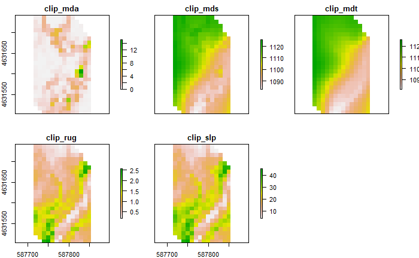

```r
plot(egv)
```

## 3.2 Calculate Pearson’s correlation among variables

Pearson’s correlation is parametric. SPearman can be used also

```r
pearson<-layerStats(egv,'pearson',na.rm=T)
print(pearson)
```

```
$`pearson correlation coefficient`
            clip_mda   clip_mds   clip_mdt    clip_rug    clip_slp
clip_mda  1.00000000 -0.2160133 -0.3518366 -0.07476501 -0.09446846
clip_mds -0.21601329  1.0000000  0.9899529 -0.21872726 -0.19485279
clip_mdt -0.35183655  0.9899529  1.0000000 -0.19977447 -0.17412025
clip_rug -0.07476501 -0.2187273 -0.1997745  1.00000000  0.99191201
clip_slp -0.09446846 -0.1948528 -0.1741203  0.99191201  1.00000000

$mean
   clip_mda    clip_mds    clip_mdt    clip_rug    clip_slp
   1.259065 1105.791183 1104.508724    0.907933   18.876328
```

you decide which variables to delete. more easier too see dendrogram. Count how many var hhas higher correlation and start deleting variables

## 3.3 Correlation dendogram

1. Transform correlation results in a dataframe

```r
cor.df<-as.data.frame(pearson)
#Check dataframe structure
head(cor.df)
```

|  | pearson.correlation.coefficient.clip_mda | pearson.correlation.coefficient.clip_mds | pearson.correlation.coefficient.clip_mdt | pearson.correlation.coefficient.clip_rug | pearson.correlation.coefficient.clip_slp | mean |
| --- | --- | --- | --- | --- | --- | --- |
| clip_mda | 1.00000000 | -0.2160133 | -0.3518366 | -0.07476501 | -0.09446846 | 1.259065 |
| clip_mds | -0.21601329 | 1.0000000 | 0.9899529 | -0.21872726 | -0.19485279 | 1105.791183 |
| clip_mdt | -0.35183655 | 0.9899529 | 1.0000000 | -0.19977447 | -0.17412025 | 1104.508724 |
| clip_rug | -0.07476501 | -0.2187273 | -0.1997745 | 1.00000000 | 0.99191201 | 0.907933 |
| clip_slp | -0.09446846 | -0.1948528 | -0.1741203 | 0.99191201 | 1.00000000 | 18.876328 |

Export dataframe

```r
write.table(cor.df,paste(path2corr,'var_correlations.csv',sep=''),sep=",")
```

2. Correlation matrix
- Transfrom correlation matrix to distances

```r
var.dist <- abs(as.dist(cor.df))
```

```
non-square matrix
```

“non-square matrix” is not an error

- Calculate dendrogram based on distance (less distance = more correlation)

```r
var.cluster <- hclust(1-var.dist)
```

- Plot dendrogram

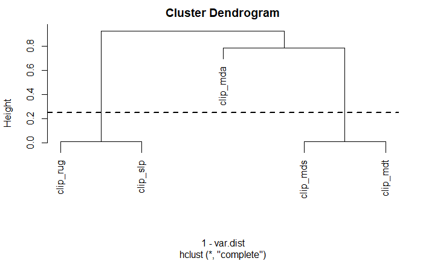

```r
plot(var.cluster)
abline(h=0.25, lty=2, lwd=2) # variables that have a correlation < 0.75
```

everything below is highly correlated. so we have 4 highly correlated, so chose 2 out of 4 highle correlated one.

you remove to analyze the response curves. if you dont remove correlated var you can’t interprete response curve. MaXENT is quite robust to correlation.

- Export correlation graph

```r
jpeg(paste(path2corr,'correlation_clusters.jpg',sep=''))
plot(var.cluster)
abline(h=0.25, lty=2, lwd=2) # variables that have a correlation < 0.75
#dev.off()
```